# Linear Modeling

Haley Reed

6/8/2020

To better understand polls, we can attempt to model the bias from polls with other measurable variables.

```r
#load the data
#in this case from 538
mydata <- read.csv("Data/raw-polls_538.csv")
```

Choose what years you would like to consider:

```r
#Establish which years you wish to use data from (between 1998 and 2020):
earlyYear=1998
lateYear=2020
```

Choose the minimum number (at least 50) of polls you wish a pollster to have before they are considered in the model:

```r
minPolls=100
```

### Data Exploration

Before modeling our data, we have a few variables in mind. Of consideration are:

- The type of race: senate, house, presidential?
- The year of the election
- The pollster conducting the poll
- Is the poll partisan? If so, which party funded it?
- What is the sample size of the poll?

It is worth separating out between pollsters. A density plot shows this:

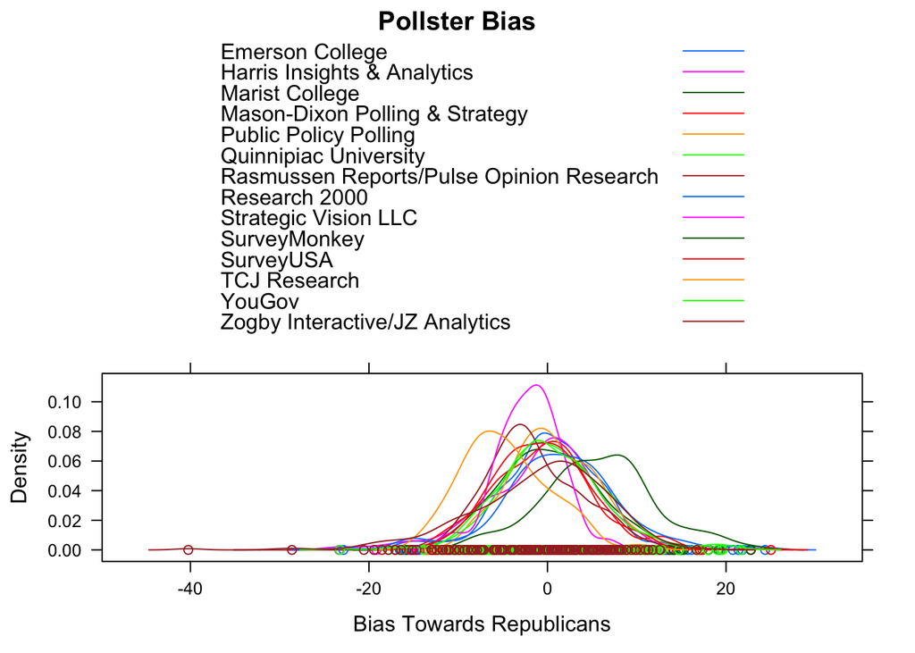

We can start this exploration by looking into bias modeled as response variable to year, categorized by pollster. It should be noted that this data excludes polls from special elections. A plot of bias by pollsters is plotted as dependent on time.

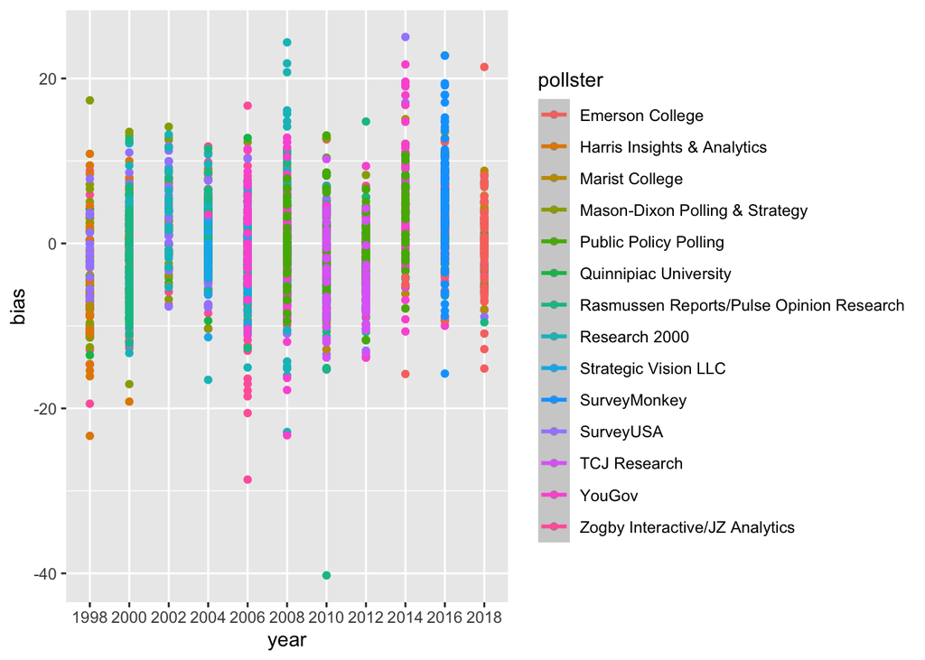

We can also take a look at the relationship between year, bias, and election type:

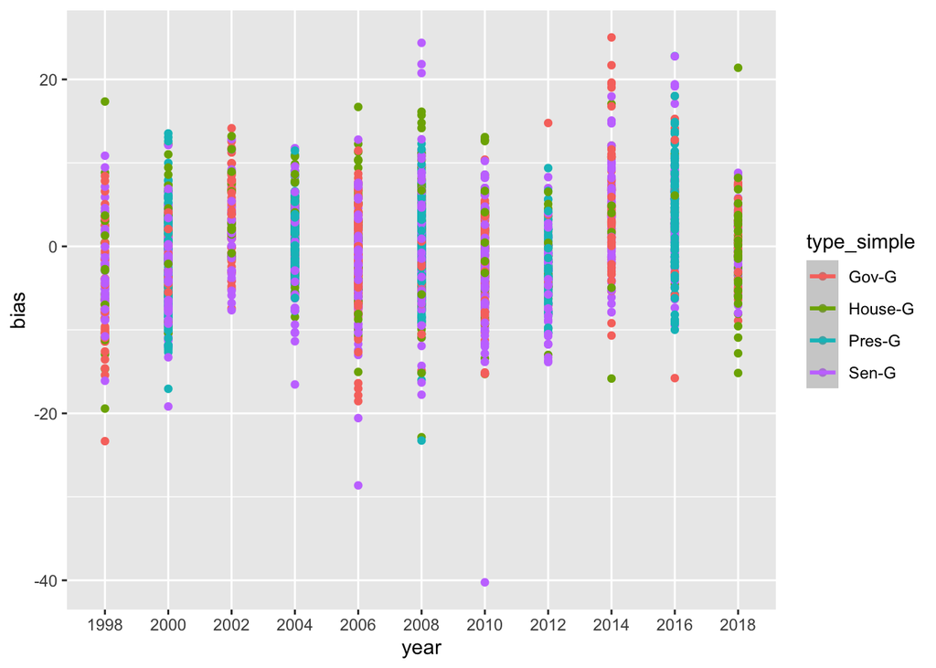

Of interest is also the relationship between partisan classification and the bias of poll results. A plot is exploring this is shown below:

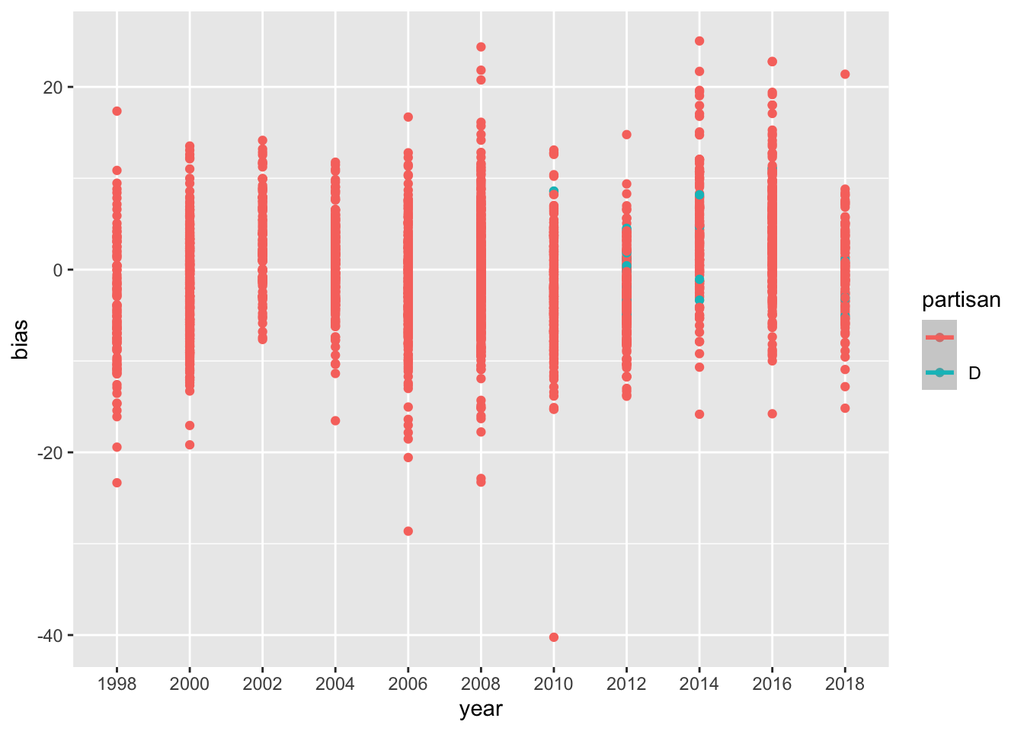

As seen above, there is overwhelmingly little partisan polls considered in our data, making it hard to make any credible statements about their apparent effect on bias. Because of this, the partisan status of polls will not be used to model polling bias.

Another factor worth considering is the sample size of our polls. Because there are a few very large polls, we will perform a log transform on the numeric sample size variable. The bias plotted as a response variable to the log-transformed sample size variable, color coded by pollster can be seen below:

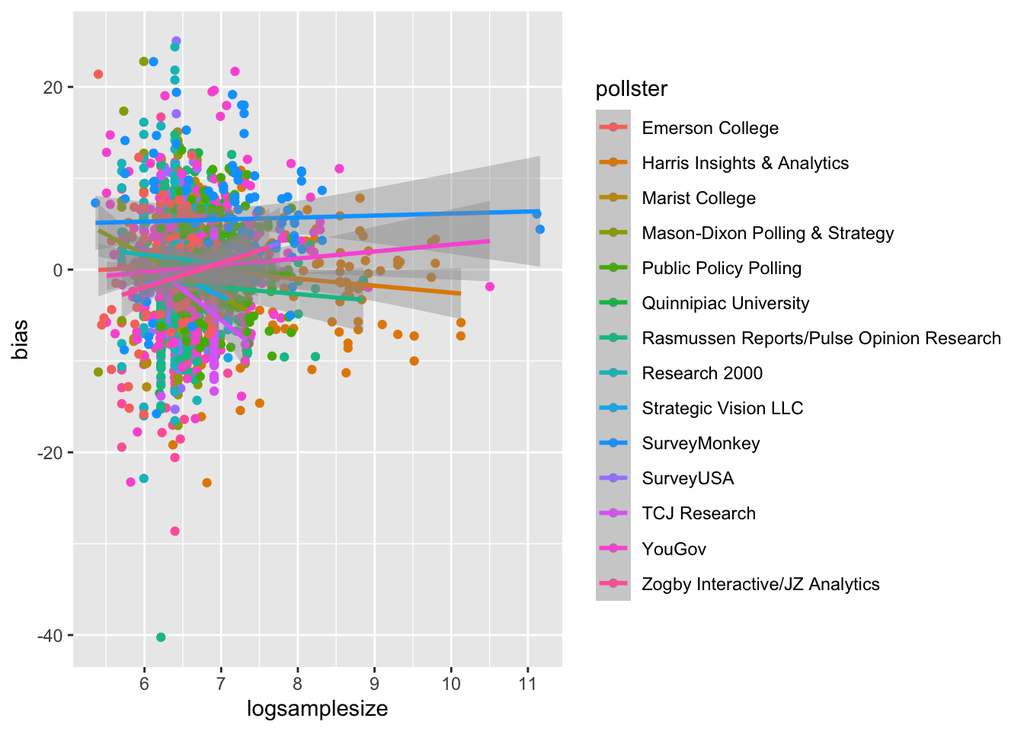

The model considered is seen below:
$$\mu [bias \~ pollster, year, type, samplesize]$$

A summary for the coefficients of this model can be seen below:

| **Characteristic** | **Beta** | **95% CI**<sup>1</sup> | **p-value** |
| --- | --- | --- | --- |
| year |  |  |  |
| 1998 | — | — |  |
| 2000 | 6.1 | 1.5, 11 | 0.010 |
| 2002 | 10 | 5.8, 15 | <0.001 |
| 2004 | 11 | 5.6, 16 | <0.001 |
| 2006 | 4.1 | 0.15, 8.1 | 0.042 |
| 2008 | 2.5 | -2.6, 7.6 | 0.3 |
| 2010 | 11 | 4.3, 17 | <0.001 |
| 2012 | 9.8 | 3.7, 16 | 0.002 |
| 2014 | 12 | 4.9, 19 | <0.001 |
| 2016 | 23 | 13, 34 | <0.001 |
| 2018 | 21 | 11, 31 | <0.001 |
| pollster |  |  |  |
| Emerson College | — | — |  |
| Harris Insights & Analytics | 15 | 5.2, 25 | 0.003 |
| Marist College | 12 | -0.65, 24 | 0.064 |
| Mason-Dixon Polling & Strategy | 16 | 6.4, 26 | 0.001 |
| Public Policy Polling | -2.3 | -7.8, 3.2 | 0.4 |
| Quinnipiac University | 15 | 3.6, 26 | 0.010 |
| Rasmussen Reports/Pulse Opinion Research | -8.0 | -19, 2.9 | 0.15 |
| Research 2000 | 16 | 1.0, 31 | 0.036 |
| Strategic Vision LLC | 14 | 4.6, 24 | 0.004 |
| SurveyMonkey | 3.8 | 1.6, 5.9 | <0.001 |
| SurveyUSA | 18 | 7.9, 28 | <0.001 |
| TCJ Research | 5.6 | -4.5, 16 | 0.3 |
| YouGov | -0.78 | -4.7, 3.1 | 0.7 |
| Zogby Interactive/JZ Analytics | 13 | 4.3, 22 | 0.004 |
| type_simple |  |  |  |
| Gov-G | — | — |  |
| House-G | 2.6 | -0.67, 5.9 | 0.12 |

[output cut: 104 more lines]

<sup>*1*</sup> CI = Confidence Interval

### Sampling Variablity Assumptions

To make sure that we can use model, we must check some sampling variability Assumptions.

Q-Q plot seems to trail off at the tails, but it appears about 95% of the points are within the 95% bounds.

The residual density plot seems centered on zero and mostly normal, with some outliers. It seems that this distrubtion matches a t-distrubtion fairly wel

The Cramer V value is only .203, indicating acceptable levels of correlation between our two discrete explanatory variables of type of poll and the pollster.

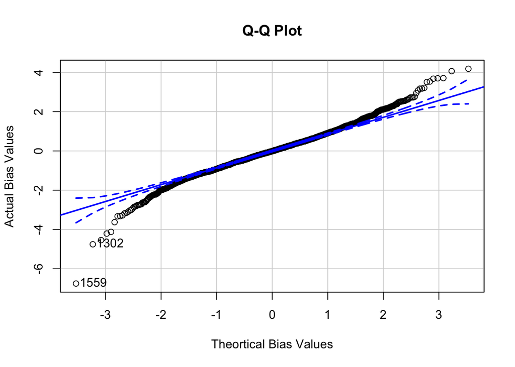

```
## [1] 1559 1302
```

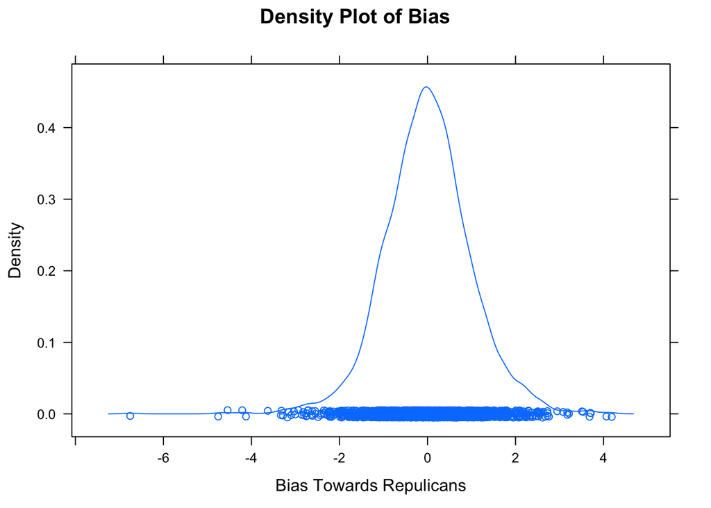

```
##
## Call: xtabs(formula = ~pollster + type_simple, data = myDataMyPollsters)
## Number of cases in table: 2426
## Number of factors: 2
## Test for independence of all factors:
##  Chisq = 303.21, df = 39, p-value = 1.301e-42
##                     X^2 df P(> X^2)
## Likelihood Ratio 328.62 39        0
## Pearson          303.21 39        0
##
## Phi-Coefficient   : NA
## Contingency Coeff.: 0.333
## Cramer's V        : 0.204
```

### Conclusions

While this model certainly isn’t perfect, it has an adjusted R-squared value of only 0.1969154, it can be helpful in helping us begin to understand how to model polling data. The final terms included in this model that are included as predictors are shown below:

- year:pollster
- year:type_simple
- year
- pollster
- type_simple
- log(samplesize)